# Binomial Mixture and Alternate Binomial Distributions PMF values

> IT WOULD BE CLEARLY BENEFICIAL FOR YOU BY USING THE RMD FILES IN THE GITHUB DIRECTORY FOR FURTHER EXPLANATION OR UNDERSTANDING OF THE R CODE FOR THE RESULTS OBTAINED IN THE VIGNETTES.

# Binomial Mixture Distributions

Binomial Mixture Distributions are developed for the purpose of fitting over dispersed Binomial outcome data. When Binomial Distribution and its conditions are violated the Binomial Mixture Distributions play a crucial role in fitting the data.

Here, we will be using plotting of Probability Mass Function values to understand how much variation can the probabilities have with the Binomial Mixture Distributions. These distributions are theoretically developed by mixing Unit Bounded distributions with the Binomial Distribution. The functions which can produce Pmf values for Binomial Mixture distributions are

- `dUniBin` - producing Pmf values primarily for Uniform Binomial Distribution.
- `dTriBin` - producing Pmf values primarily for Triangular Binomial Distribution.
- `dBetaBin` - producing Pmf values primarily for Beta-Binomial Distribution.
- `dKumBin` - producing Pmf values primarily for Kumaraswamy Binomial Distribution.
- `dGHGBB` - producing Pmf values primarily for Gaussian Hyper-geometric Generalized Beta-Binomial Distribution.
- `dMcGBB` - producing Pmf values primarily for McDonald Generalized Beta-Binomial Distribution.
- `dGammaBin` - producing Pmf values primarily for Gamma Binomial Distribution.
- `dGrassiaIIBin` - producing Pmf values primarily for Grassia II Binomial Distribution.

When the no of shape parameters increase plotting variation of pmf values is difficult therefore special Pmf plot functions are developed. They are namely

- `dBetaBinplot` - plot function to Beta-Binomial Distribution.
- `dKumBinplot` - plot function to Kumaraswamy Binomial Distribution.
- `dGHGBBplot` - plot function to Gaussian Hyper-geometric Generalized Beta-Binomial Distribution.
- `dMcGBBplot` - plot function to McDonald Generalized Beta-Binomial Distribution.
- `dGammaBinplot` - plot function to Gamma Binomial Distribution.
- `dGrassiaIIBinplot` - plot function Grassia II Binomial Distribution.

## Probability Mass Function values for Uniform Binomial Distribution

Uniform Binomial distribution is the earliest development with least amount of over dispersed Binomial Random variables. There is no shape parameter which make this distribution very limited. Below is the of pmf values

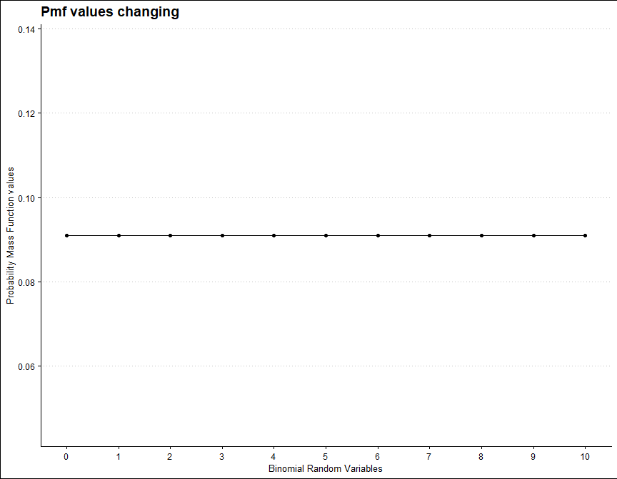

```r
brv <- 0:10
pmfv <- dUniBin(brv,max(brv))$pdf
data <- data.frame(brv,pmfv)
ggplot(data)+
  geom_point(aes(x=data$brv,y=data$pmfv))+
  geom_line(aes(x=data$brv,y=data$pmfv))+
  xlab("Binomial Random Variables")+
  ylab("Probability Mass Function values")+
  ggtitle("Pmf values changing")+
  ggthemes::theme_clean()+
  scale_x_continuous(breaks=seq(0,10,by=1))
```

## Probability Mass Function values for Triangular Binomial Distribution

Triangular Binomial Distribution has one parameter which has immense effect on the pmf values. Which is the mode parameter in the domain region of zero and one. According to the changes made in mode parameter pmf values will react and it has been plotted below

```r
brv <- seq(0,15,by=1)
mode <- seq(0.02,0.98,by=0.02)
length(mode) #variables
```

```
## [1] 49
```

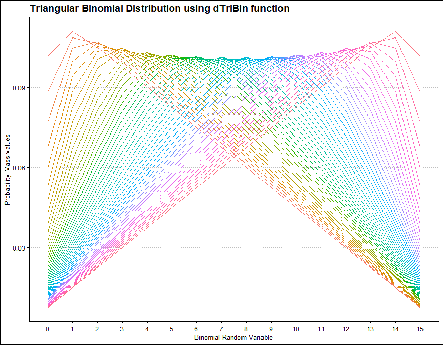

```r
output <- matrix(ncol =length(mode) ,nrow=length(brv))
for (i in 1:length(mode))
  {
   output[,i]<-dTriBin(brv,max(brv),mode[i])$pdf
  }
data <- data.frame(brv,output)
data <- melt(data,id.vars ="brv" )
ggplot(data,aes(brv,value,col=variable))+
  geom_line()+guides(fill=FALSE,color=FALSE)+
  xlab("Binomial Random Variable")+
  ylab("Probability Mass values")+
  ggthemes::theme_clean()+
  ggtitle("Triangular Binomial Distribution using dTriBin function")+
  scale_x_continuous(breaks=seq(0,15,by=1))
```

## Probability Mass Function values for Beta-Binomial Distribution

Beta-Binomial Distribution has two shape parameters which influence the pmf values. They are namely a and b. These two parameters are inherited from the Beta distribution when mixing it to the Binomial Distribution. Pmf values are plotted below according to a and b values change

- a,b are in the domain region of above zero.

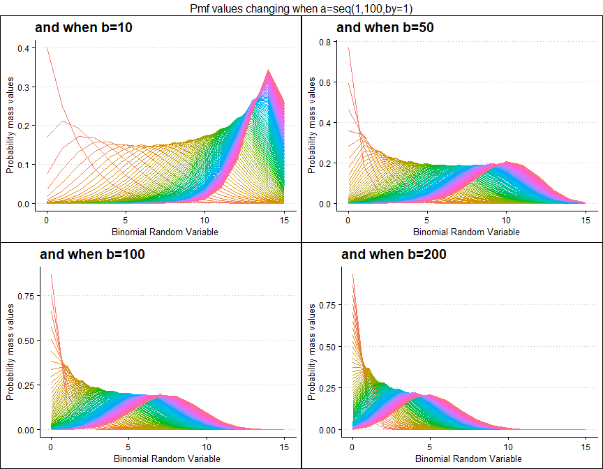

```r
 b10 <- dBetaBinplot(a=seq(1,100,by=1),b=10,plot_title="and when b=10",a_seq= T)
 b50 <- dBetaBinplot(a=seq(1,100,by=1),b=50,plot_title="and when b=50",a_seq= T)
b100 <- dBetaBinplot(a=seq(1,100,by=1),b=100,plot_title="and when b=100",a_seq= T)
b200 <- dBetaBinplot(a=seq(1,100,by=1),b=200,plot_title="and when b=200",a_seq= T)

grid.arrange(b10,b50,b100,b200,nrow=2,top="Pmf values changing when a=seq(1,100,by=1)")
```

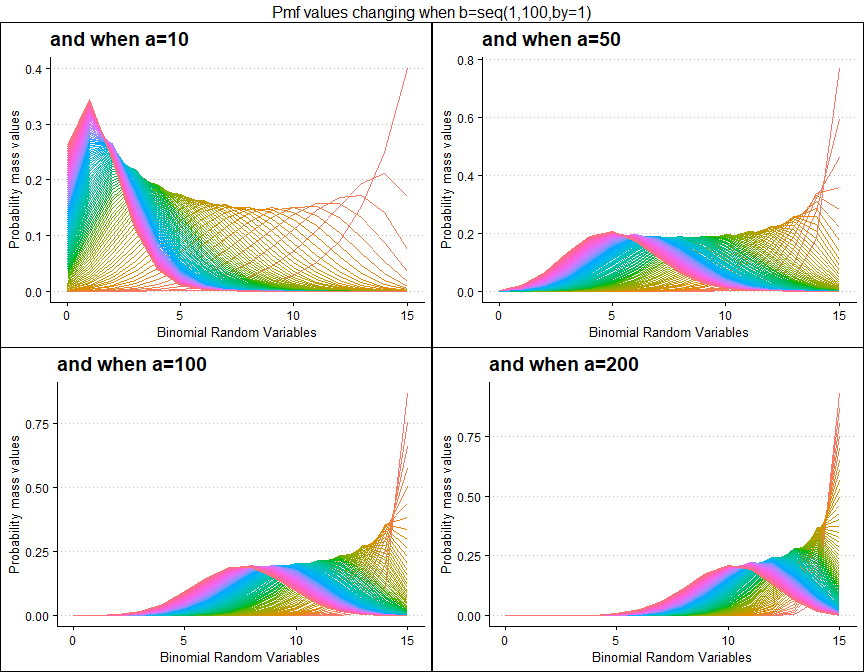

```r
 a10 <- dBetaBinplot(b=seq(1,100,by=1),a=10,plot_title="and when a=10",a_seq= F)
 a50 <- dBetaBinplot(b=seq(1,100,by=1),a=50,plot_title="and when a=50",a_seq= F)
a100 <- dBetaBinplot(b=seq(1,100,by=1),a=100,plot_title="and when a=100",a_seq= F)
a200 <- dBetaBinplot(b=seq(1,100,by=1),a=200,plot_title="and when a=200",a_seq= F)

grid.arrange(a10,a50,a100,a200,nrow=2,top="Pmf values changing when b=seq(1,100,by=1)")
```

## Probability Mass Function values for Kumaraswamy Binomial Distribution

Kumaraswamy Binomial distribution is similar to Beta-Binomial distribution with two shape parameters. Mixing Kumaraswamy distribution with Binomial distribution results in Kumaraswamy Binomial Distribution. The two shape parameters are a and b. Below are the plots for describing how pmf values change with respective to those a and b shape parameters.

- a,b are in the domain region of above zero.
- iteration parameter replacing the infinity value in the summation part.

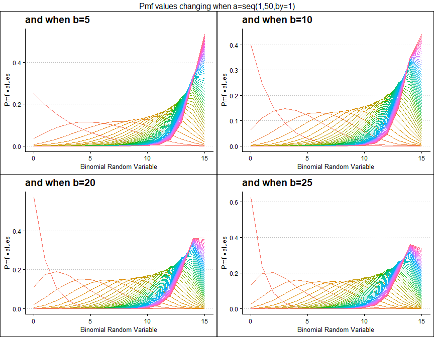

```r
 b5 <- dKumBinplot(a=seq(1,50,by=1),b=5,plot_title="and when b=5",a_seq=T)
b10 <- dKumBinplot(a=seq(1,50,by=1),b=10,plot_title="and when b=10",a_seq=T)
b20 <- dKumBinplot(a=seq(1,50,by=1),b=20,plot_title="and when b=20",a_seq=T)
b25 <- dKumBinplot(a=seq(1,50,by=1),b=25,plot_title="and when b=25",a_seq=T)

grid.arrange(b5,b10,b20,b25,nrow=2,top="Pmf values changing when a=seq(1,50,by=1)")
```

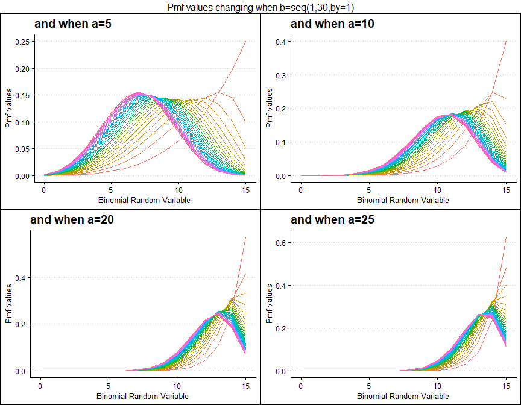

```r
 a5 <- dKumBinplot(b=seq(1,30,by=1),a=5,plot_title="and when a=5",a_seq=F)
a10 <- dKumBinplot(b=seq(1,30,by=1),a=10,plot_title="and when a=10",a_seq=F)
a20 <- dKumBinplot(b=seq(1,30,by=1),a=20,plot_title="and when a=20",a_seq=F)
a25 <- dKumBinplot(b=seq(1,30,by=1),a=25,plot_title="and when a=25",a_seq=F)

grid.arrange(a5,a10,a20,a25,nrow=2,top="Pmf values changing when b=seq(1,30,by=1)")
```